# HW_01

Masum Billah

2026-02-18

#### a. State your assumptions and write the rules of the simulation in a manner similar to what I did in the notes.

Here, we are assuming the following rules:

1. The data are normally distributed.
2. The data points are identically and independently distributed.
3. The true standard deviation is known for the Z test.
4. The true standard deviation is unknown for the t test.

Rules of the Simulation

1. Calculate the critical values for the t-test and Z-test using the user-defined confidence interval.
2. Generate normally distributed i.i.d. data using the user-defined mu and sd.
3. Calculate the standard error for both distributions based on assumptions.
4. Construct the confidence intervals for the t-statistic and Z-statistic.
5. Increase the individual counter for each distribution if the confidence interval contains the true mu.
6. Repeat steps 2 to 5 for R number of replicates.
7. Finally, divide the individual counters by the number of replicates to obtain true coverage probability.

#### b. Explain how these rules are translated into a computer program and how your function works.

```
Specify Parameters
  p = target coverage probability of the CI
  mu = true mean for the simulated data
  sd = true standard deviation for the simulated data
  N = number of sample
  R = number of replicates

  initialize t_cov = 0
  initialize z_cov = 0
  calculate t_crit = qt(1 - (1 - p) / 2, df = N - 1)
  calculate z_crit = qnorm(1 - (1 - p) / 2)

  Loop over replicates
  {
    generate sample = Normal(mu, sd = sd, size = N)
    compute t_se = sd(sample) / sqrt(N) and z_se = sd / sqrt(N)
    construct the confidence interval:
    t_ci = [mean(sample) - t_crit * t_se, mean(sample) + t_crit * t_se]
    z_ci = [mean(sample) - z_crit * z_se, mean(sample) + z_crit * z_se]
    check true coverage:
    if (mu >= t_ci[1] and mu <= t_ci[2]) then t_cov += 1
    if (mu >= z_ci[1] and mu <= z_ci[2]) then z_cov += 1
    store the result
}
return t_cov/R and z_cov/R
```

##### The function CISim(p, mu, sd, N, R) has been implemented as follows:

```r
CISim <- function(p=0.95, mu=0, sd=1, N=30, R=1000){

    # p:  target coverage probability of the CI (e.g. p=0.95 for a 95% CI).
    # mu: population mean for the simulated data. Default value=zero.
    # sd: population standard deviation for the simulated data. Default value=one.
    # N:  sample size for the simulated data. Default value=30.
    # R:  number of simulation replicates. Default value=1000.

    t_cov = 0
    z_cov = 0

    # calculate critical values
    t_crit =  qt(1 - (1 - p)/2, df = N - 1)
    z_crit = qnorm(1 - (1 - p)/2)

    for (i in 1:R){
      rv = rnorm(n=N, mean=mu, sd=sd)

      avg = mean(rv)
      # calculate standard errors
      t_se = sd(rv)/sqrt(N)
      z_se = sd / sqrt(N)

      # calculate confidence interval
      t_lower = avg - t_crit * t_se
      t_upper = avg + t_crit * t_se

      # calculate confidence interval
      z_lower = avg - z_crit * z_se
      z_upper = avg + z_crit * z_se

      # check the true coverage probability
      if (mu >= t_lower && mu <= t_upper) t_cov = t_cov + 1
      if (mu >= z_lower && mu <= z_upper) z_cov = z_cov + 1
    }
    prob = c(t_cov/R, z_cov/R)
    return(prob)
}

# get true coverage probability
prob = CISim()
{
#print the output
cat("method coverage\n")
cat(sprintf(" t %.3f\n", prob[1]))
cat(sprintf(" Z %.3f\n", prob[2]))
}
```

```
## method coverage
##  t 0.946
##  Z 0.950
```

#### c. Use your function to explore the performance of the t-based and Z-based confidence intervals as you vary different parameters. Does the coverage probability always approximate its target value? Write a short report

To explore the true coverage probability for t-based and Z-based confidence intervals, we simulated the function CISim() using different combinations of parameters. For the first scenario, we increased the true mean sequentially in 0.5 increments to check the true coverage probability for both t and Z-statistics. The plot below shows that the true coverage remains close to 95% in most cases.

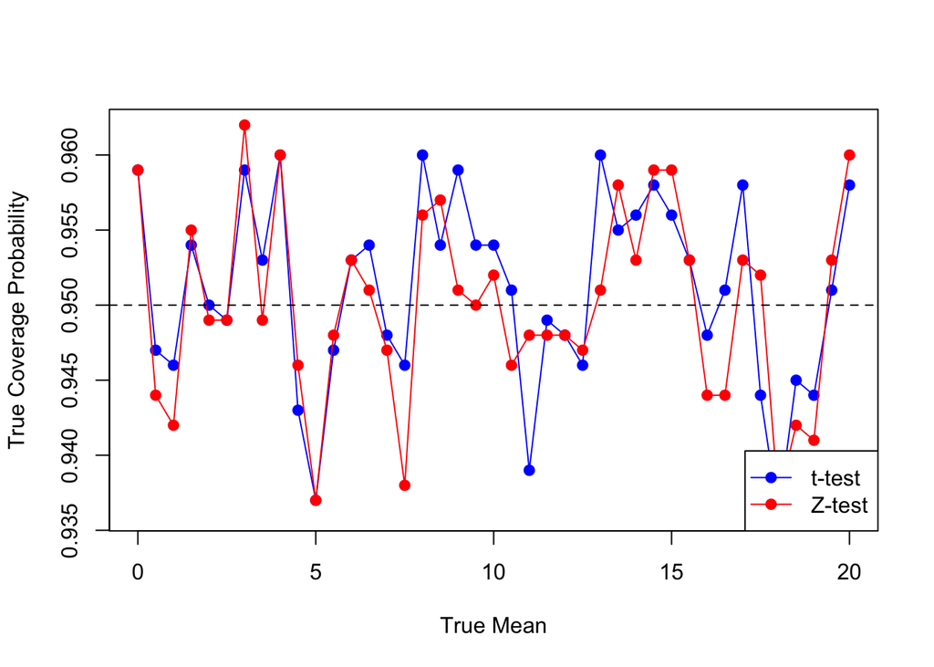

```r
means = seq(0, 20, 0.5)

out = matrix(nrow = length(means), ncol=2) # matrix to store true coverage probability

for (i in 1:length(means)){

  p = CISim (p=0.95, mu=means[i], sd=1, N=30, R=1000)
  out[i, 1] = p[1]
  out[i, 2] = p[2]
}

{
  # plot true coverage for t
  plot(means, out[,1], col="blue", pch=19, type = 'o',
       xlab = "True Mean", ylab = "True Coverage Probability",
       ylim = range(c(out[,1], out[,2])))

  # plot true coverage for Z
  lines(means, out[,2], col="red", pch=19, type = 'o')

  # 95% confidence interval
  abline(h = 0.95, lty = 2)
  legend("bottomright", legend = c("t-test", "Z-test"), col = c("blue", "red"), pch = 19, lty = 1)
}
```

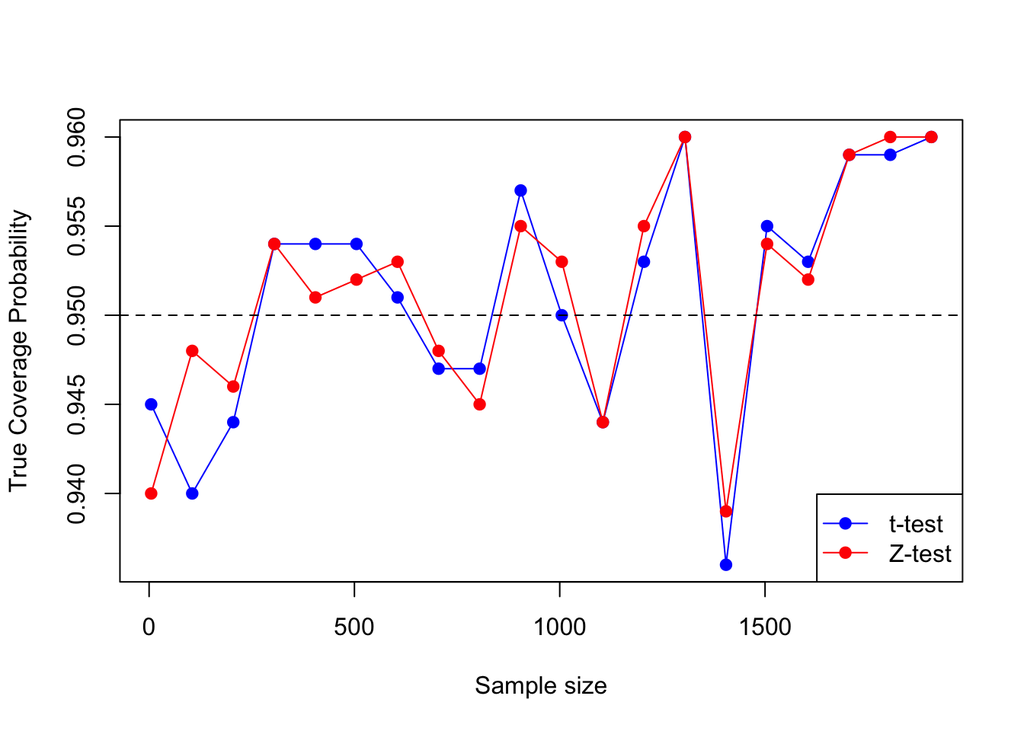

```r
nsample = seq(5, 2000, 100)
out = matrix(nrow = length(nsample), ncol=2) # matrix to store true coverage probability
for (i in 1:length(nsample)){
  p = CISim (p=0.95, mu=0, sd=1, N=nsample[i], R=1000)
  out[i, 1] = p[1]
  out[i, 2] = p[2]
}

{
  # plot true coverage for t
  plot(nsample, out[,1], col="blue", pch=19, type = 'o',
       xlab = "Sample size", ylab = "True Coverage Probability",
       ylim = range(c(out[,1], out[,2])))

  # plot true coverage for Z
  lines(nsample, out[,2], col="red", pch=19, type = 'o')

  # 95% confidence interval
  abline(h = 0.95, lty = 2)
  legend("bottomright", legend = c("t-test", "Z-test"), col = c("blue", "red"), pch = 19, lty = 1)
}
```

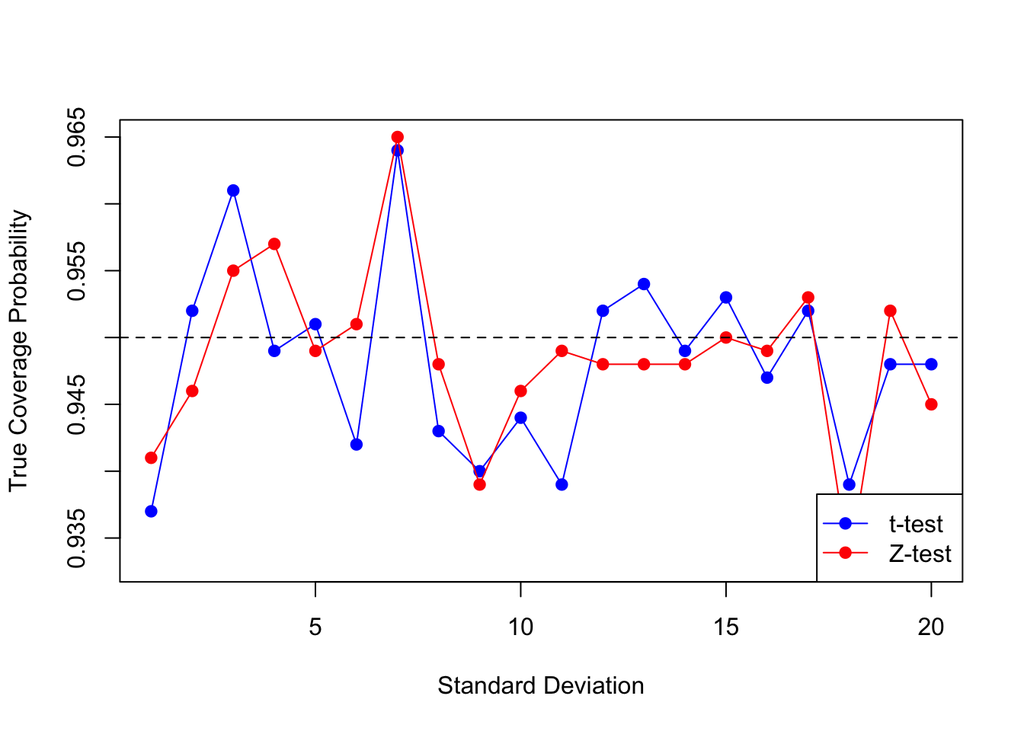

```r
sd = seq(1, 20, 1)
out = matrix(nrow = length(sd), ncol=2) # matrix to store true coverage probability
for (i in 1:length(nsample)){
  p = CISim (p=0.95, mu=0, sd=sd[i], N=30, R=1000)
  out[i, 1] = p[1]
  out[i, 2] = p[2]
}

{
  # plot true coverage for t
  plot(sd, out[,1], col="blue", pch=19, type = 'o',
       xlab = "Standard Deviation", ylab = "True Coverage Probability",
       ylim = range(c(out[,1], out[,2])))

  # plot true coverage for Z
  lines(sd, out[,2], col="red", pch=19, type = 'o')

  # 95% confidence interval
  abline(h = 0.95, lty = 2)
  legend("bottomright", legend = c("t-test", "Z-test"), col = c("blue", "red"), pch = 19, lty = 1)
}
```

In conclusion, we simulated three different scenarios including different true means, standard deviations, and sample sizes to explore the performance of t-based and Z-based confidence intervals. Across all cases, the true mean was captured within the 95% confidence interval approximately 95% of the time for both t and Z statistics.